# Assignment-1 for “Reproducible Research

## Loading and preprocessing the data

1. Load the data

```r
data=read.csv("activity.csv", header=T)
head(data)
```

```
##   steps       date interval
## 1    NA 2012-10-01        0
## 2    NA 2012-10-01        5
## 3    NA 2012-10-01       10
## 4    NA 2012-10-01       15
## 5    NA 2012-10-01       20
## 6    NA 2012-10-01       25
```

## What is mean total number of steps taken per day?

1.Calculate the total number of steps taken per day and Process/transform the data into a format suitable for your analysis

```r
sum_data=tapply(data$steps, data$date, sum)
data_transform=transform(sum_data)
data_transform$date= row.names(data_transform)
 names(data_transform)= c("counts", "date")
dim(data_transform)
```

```
## [1] 61  2
```

```r
head(data_transform)
```

```
##            counts       date
## 2012-10-01     NA 2012-10-01
## 2012-10-02    126 2012-10-02
## 2012-10-03  11352 2012-10-03
## 2012-10-04  12116 2012-10-04
## 2012-10-05  13294 2012-10-05
## 2012-10-06  15420 2012-10-06
```

2.Make a histogram of the total number of steps taken each day

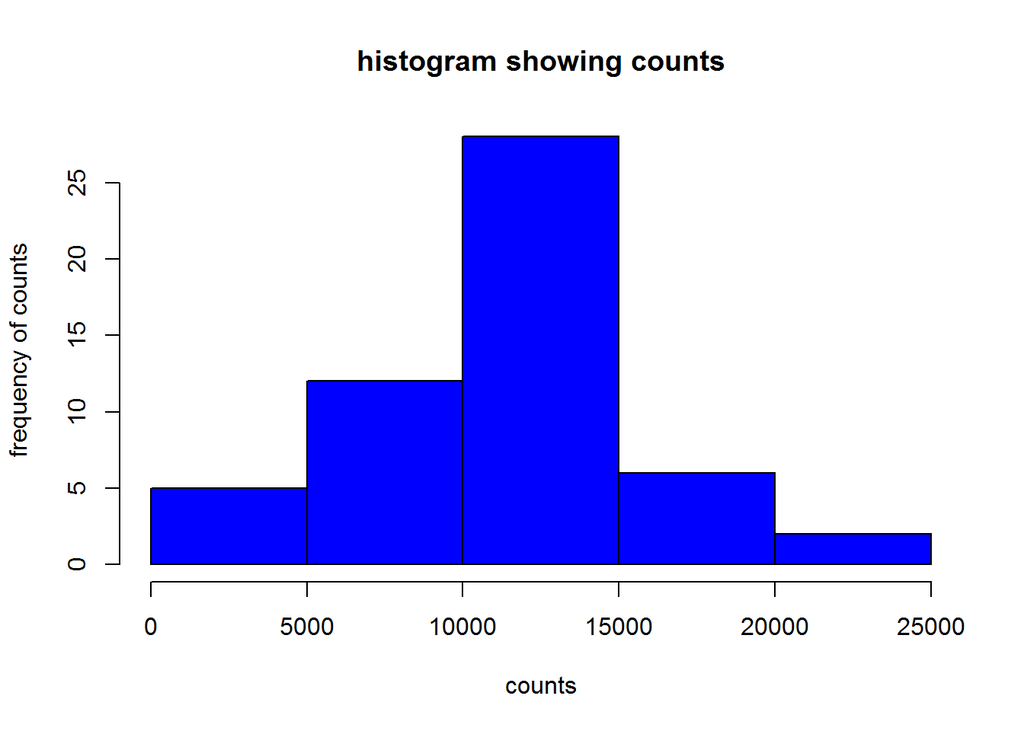

```r
hist(data_transform$counts, xlab= "counts", ylab="frequency of counts", col="blue", main="histogram showing counts")
```

3.Calculate and report the mean and median of the total number of steps taken per day

```r
avg=mean(data_transform$counts, na.rm=TRUE)
avg
```

```
## [1] 10766.19
```

```r
med=median(data_transform$counts, na.rm=TRUE)
med
```

```
## [1] 10765
```

## What is the average daily activity pattern:-

1.Make a time series plot of the 5-minute interval (x-axis) and the average number of steps taken, averaged across all days (y-axis)

```r
pattern = tapply(data$steps,data$interval,mean , na.rm=TRUE )
dim(pattern)
```

```
## [1] 288
```

```r
patt=transform(pattern)
patt$interval= row.names(patt)
 names(patt)= c("avg_steps", "interval")
head(patt)
```

```
##    avg_steps interval
## 0  1.7169811        0
## 5  0.3396226        5
## 10 0.1320755       10
## 15 0.1509434       15
## 20 0.0754717       20
## 25 2.0943396       25
```

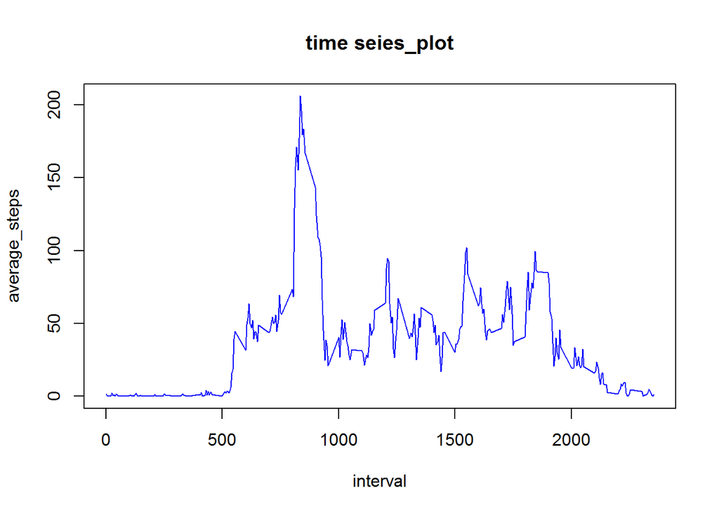

```r
plot(patt$interval, patt$avg_steps, type="l", col="blue",xlab="interval", ylab="average_steps", main="time seies_plot")
```

2.Which 5-minute interval, on average across all the days in the dataset, contains the maximum number of steps?

```r
avgstep=which.max(patt$avg_steps)
names(avgstep)
```

```
## [1] "835"
```

## Imputing missing values

1.Calculate and report the total number of missing values in the dataset (i.e. the total number of rows with NAs)

```r
sum(is.na(data))
```

```
## [1] 2304
```

2.Devise a strategy for filling in all of the missing values in the dataset. use the mean for that day, or the mean for that 5-minute interval, etc.

```r
avg=aggregate(steps ~ interval,data=data, mean)
Imp_data=as.numeric()
for(i in 1: nrow(data)){
  val=data[i,]
  if(is.na(val$steps)){
    steps = subset(avg,interval==val$interval)$steps
  } else {
    steps = val$steps
  }
    Imp_data <- c(Imp_data, steps)
  }
Impute_data=data
Impute_data$steps=Imp_data
```

3.Create a new dataset that is equal to the original dataset but with the missing data filled in.

```r
head(Impute_data)
```

```
##       steps       date interval
## 1 1.7169811 2012-10-01        0
## 2 0.3396226 2012-10-01        5
## 3 0.1320755 2012-10-01       10
## 4 0.1509434 2012-10-01       15
## 5 0.0754717 2012-10-01       20
## 6 2.0943396 2012-10-01       25
```

```r
dim(Impute_data)
```

```
## [1] 17568     3
```

4.Make a histogram of the total number of steps taken each day and Calculate and report the mean and median total number of steps taken per day. Do these values differ from the estimates from the first part of the assignment? What is the impact of imputing missing data on the estimates of the total daily number of steps?

```r
new_data=aggregate(steps ~ date, data=Impute_data, sum)
head(new_data)
```

```
##         date    steps
## 1 2012-10-01 10766.19
## 2 2012-10-02   126.00
## 3 2012-10-03 11352.00
## 4 2012-10-04 12116.00
## 5 2012-10-05 13294.00
## 6 2012-10-06 15420.00
```

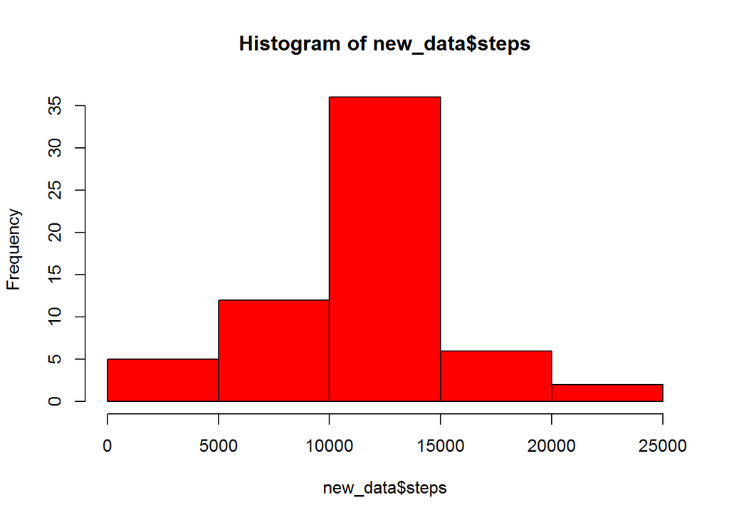

```r
hist(new_data$steps, col="red")
```

```r
mean(new_data$steps)
```

```
## [1] 10766.19
```

```r
median(new_data$steps)
```

```
## [1] 10766.19
```

## Are there differences in activity patterns between weekdays and weekends?

1.Create a new factor variable in the dataset with two levels - “weekday” and “weekend” indicating whether a given date is a weekday or weekend day

```r
Impute_data$date=as.Date(strptime(Impute_data$date, format="%Y-%m-%d"))
Impute_data$day= weekdays(Impute_data$date)
for(i in 1:nrow(Impute_data))
  { if(Impute_data[i,]$day %in% c("Saturday","Sunday"))
    {
    Impute_data[i,]$day ="weekend"
    }else{
      Impute_data[i,]$day ="weekday"
      }
    }
 head(Impute_data)
```

```
##       steps       date interval     day
## 1 1.7169811 2012-10-01        0 weekday
## 2 0.3396226 2012-10-01        5 weekday
## 3 0.1320755 2012-10-01       10 weekday
## 4 0.1509434 2012-10-01       15 weekday
## 5 0.0754717 2012-10-01       20 weekday
## 6 2.0943396 2012-10-01       25 weekday
```

```r
dim(Impute_data)
```

```
## [1] 17568     4
```

```r
ser=aggregate(Impute_data$steps ~ Impute_data$interval +as.factor(Impute_data$day),data= Impute_data,mean)
names(ser)=c("interval","days", "steps")
head(ser)
```

```
##   interval    days      steps
## 1        0 weekday 2.25115304
## 2        5 weekday 0.44528302
## 3       10 weekday 0.17316562
## 4       15 weekday 0.19790356
## 5       20 weekday 0.09895178
## 6       25 weekday 1.59035639
```

2.Make a panel plot containing a time series plot f the 5-minute interval (x-axis) and the average number of steps taken, averaged across all weekday days or weekend days (y-axis)

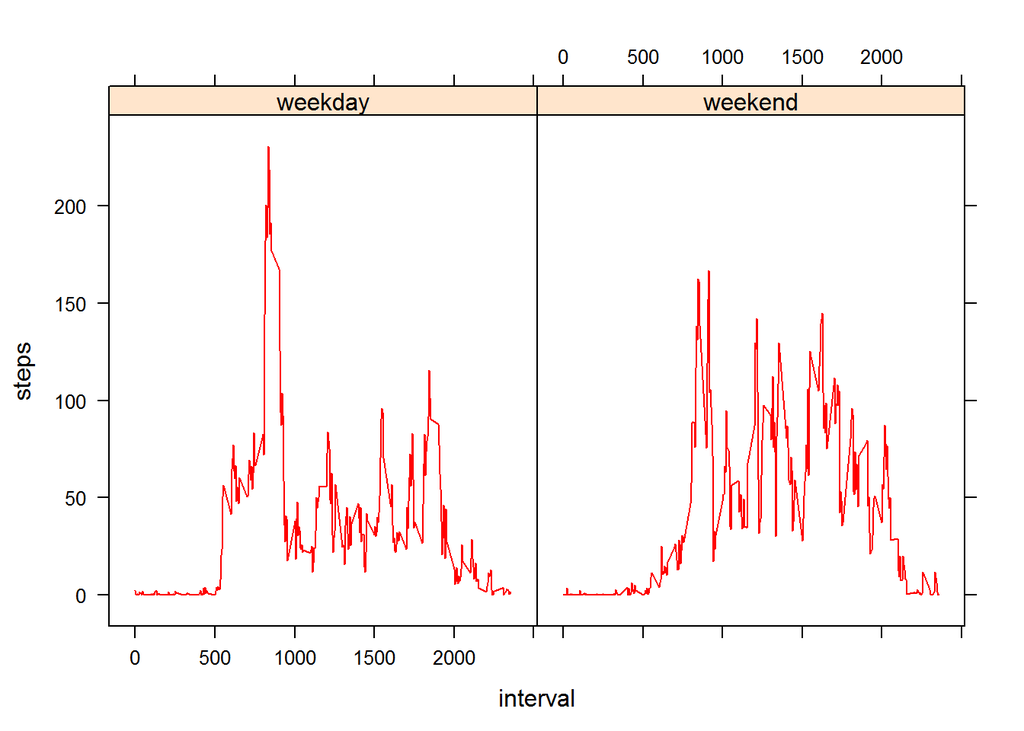

```r
library(lattice)
p <- xyplot(steps ~ interval | factor(days), data=ser, type = 'l',col=c("red", "blue"))
print (p)
```